# Practical Machine Learning Project

Marijus B

### Libraries

```r
library(caret)
library(rattle)
```

```r
library(rpart)
library(rpart.plot)
library(randomForest)
library(corrplot)
library(gbm)
library(data.table)
library(kernlab)
library(ggplot2)
library(MASS)
library(tidyverse)
library(data.table)
```

## Background

Using devices such as Jawbone Up, Nike FuelBand, and Fitbit it is now possible to collect a large amount of data about personal activity relatively inexpensively. These type of devices are part of the quantified self movement – a group of enthusiasts who take measurements about themselves regularly to improve their health, to find patterns in their behavior, or because they are tech geeks. One thing that people regularly do is quantify how much of a particular activity they do, but they rarely quantify how well they do it. In this project, your goal will be to use data from accelerometers on the belt, forearm, arm, and dumbell of 6 participants. They were asked to perform barbell lifts correctly and incorrectly in 5 different ways.

## Project

The main goal of the project is predict the manner in which exercises were performed by six participants and it is labeled as “classe” in the training data set.

Data for the analysis consists of training and test data sets.

Data will be tested with 4 different models : *Classification Tree* , *Random Forest* , *Gradient Boosting Method* and *Linear Discriminant Analysis*.

WLE dataset for this project is a courtesy of: Velloso, E.; Bulling, A.; Gellersen, H.; Ugulino, W.; Fuks, H. Qualitative Activity Recognition of Weight Lifting Exercises. Proceedings of 4th International Conference in Cooperation with SIGCHI (Augmented Human ’13) . Stuttgart, Germany: ACM SIGCHI, 2013.

## Getting Data

Data is obtained from:

https://d396qusza40orc.cloudfront.net/predmachlearn/pml-training.csv

https://d396qusza40orc.cloudfront.net/predmachlearn/pml-testing.csv

#### Training Data

```r
trainingData <- read.csv(url("https://d396qusza40orc.cloudfront.net/predmachlearn/pml-training.csv"),header=TRUE)
table(trainingData$classe)
```

```
##
##    A    B    C    D    E
## 5580 3797 3422 3216 3607
```

```r
#str(trainingData)
dim(trainingData)
```

```
## [1] 19622   160
```

```r
#summary(trainingData)
```

#### Testing Data

```r
testingData <- read.csv(url("https://d396qusza40orc.cloudfront.net/predmachlearn/pml-testing.csv"),header=TRUE)
table(testingData$classe)
```

```
## < table of extent 0 >
```

```r
#str(testingData)
dim(testingData)
```

```
## [1]  20 160
```

```r
#summary(testingData)
```

## Cleaning Data Sets

#### Removing variables from the data sets that are close to zero:

```r
NSV <- nearZeroVar(trainingData,saveMetrics=TRUE)
NSV
```

```
##                            freqRatio percentUnique zeroVar   nzv
## X                           1.000000  100.00000000   FALSE FALSE
## user_name                   1.100679    0.03057792   FALSE FALSE
## raw_timestamp_part_1        1.000000    4.26562022   FALSE FALSE
## raw_timestamp_part_2        1.000000   85.53154622   FALSE FALSE
## cvtd_timestamp              1.000668    0.10192641   FALSE FALSE
## new_window                 47.330049    0.01019264   FALSE  TRUE
## num_window                  1.000000    4.37264295   FALSE FALSE
## roll_belt                   1.101904    6.77810621   FALSE FALSE
## pitch_belt                  1.036082    9.37722964   FALSE FALSE
## yaw_belt                    1.058480    9.97349913   FALSE FALSE
## total_accel_belt            1.063160    0.14779329   FALSE FALSE
## kurtosis_roll_belt       1921.600000    2.02323922   FALSE  TRUE
## kurtosis_picth_belt       600.500000    1.61553358   FALSE  TRUE
## kurtosis_yaw_belt          47.330049    0.01019264   FALSE  TRUE
## skewness_roll_belt       2135.111111    2.01304658   FALSE  TRUE
## skewness_roll_belt.1      600.500000    1.72255631   FALSE  TRUE
## skewness_yaw_belt          47.330049    0.01019264   FALSE  TRUE
## max_roll_belt               1.000000    0.99378249   FALSE FALSE
## max_picth_belt              1.538462    0.11211905   FALSE FALSE
## max_yaw_belt              640.533333    0.34654979   FALSE  TRUE
## min_roll_belt               1.000000    0.93772296   FALSE FALSE
## min_pitch_belt              2.192308    0.08154113   FALSE FALSE
## min_yaw_belt              640.533333    0.34654979   FALSE  TRUE
## amplitude_roll_belt         1.290323    0.75425543   FALSE FALSE
## amplitude_pitch_belt        3.042254    0.06625217   FALSE FALSE
## amplitude_yaw_belt         50.041667    0.02038528   FALSE  TRUE
## var_total_accel_belt        1.426829    0.33126083   FALSE FALSE
## avg_roll_belt               1.066667    0.97339721   FALSE FALSE
## stddev_roll_belt            1.039216    0.35164611   FALSE FALSE
## var_roll_belt               1.615385    0.48924676   FALSE FALSE
## avg_pitch_belt              1.375000    1.09061258   FALSE FALSE
## stddev_pitch_belt           1.161290    0.21914178   FALSE FALSE
## var_pitch_belt              1.307692    0.32106819   FALSE FALSE
## avg_yaw_belt                1.200000    1.22311691   FALSE FALSE
## stddev_yaw_belt             1.693878    0.29558659   FALSE FALSE
## var_yaw_belt                1.500000    0.73896647   FALSE FALSE
## gyros_belt_x                1.058651    0.71348486   FALSE FALSE
## gyros_belt_y                1.144000    0.35164611   FALSE FALSE
## gyros_belt_z                1.066214    0.86127816   FALSE FALSE
```

[output cut: 106 more lines]

```
## stddev_pitch_forearm       41.500000    1.64611151   FALSE  TRUE
## var_pitch_forearm          83.000000    1.65120783   FALSE  TRUE
## avg_yaw_forearm            83.000000    1.65120783   FALSE  TRUE
## stddev_yaw_forearm         85.000000    1.64101519   FALSE  TRUE
## var_yaw_forearm            85.000000    1.64101519   FALSE  TRUE
## gyros_forearm_x             1.059273    1.51870350   FALSE FALSE
## gyros_forearm_y             1.036554    3.77637346   FALSE FALSE
## gyros_forearm_z             1.122917    1.56457038   FALSE FALSE
## accel_forearm_x             1.126437    4.04647844   FALSE FALSE
## accel_forearm_y             1.059406    5.11160942   FALSE FALSE
## accel_forearm_z             1.006250    2.95586586   FALSE FALSE
## magnet_forearm_x            1.012346    7.76679238   FALSE FALSE
## magnet_forearm_y            1.246914    9.54031189   FALSE FALSE
## magnet_forearm_z            1.000000    8.57710733   FALSE FALSE
## classe                      1.469581    0.02548160   FALSE FALSE
```

```r
nsv <- nearZeroVar(trainingData)
nsv
```

```
##  [1]   6  12  13  14  15  16  17  20  23  26  51  52  53  54  55  56  57  58  59
## [20]  69  70  71  72  73  74  75  78  79  81  82  87  88  89  90  91  92  95  98
## [39] 101 125 126 127 128 129 130 131 133 134 136 137 139 142 143 144 145 146 147
## [58] 148 149 150
```

```r
training <- trainingData[, -nsv]
testing  <- testingData[, -nsv]
dim(training)
```

```
## [1] 19622   100
```

```r
dim(testing)
```

```
## [1]  20 100
```

#### Removing missing values, NAs from data sets:

```r
indColToRemove <- which(colSums(is.na(trainingData) |trainingData=="")>0.8*dim(trainingData)[1])
training <- trainingData[,-indColToRemove]
str(training)
```

```
## 'data.frame':    19622 obs. of  60 variables:
##  $ X                   : int  1 2 3 4 5 6 7 8 9 10 ...
##  $ user_name           : Factor w/ 6 levels "adelmo","carlitos",..: 2 2 2 2 2 2 2 2 2 2 ...
##  $ raw_timestamp_part_1: int  1323084231 1323084231 1323084231 1323084232 1323084232 1323084232 1323084232 1323084232 1323084232 1323084232 ...
##  $ raw_timestamp_part_2: int  788290 808298 820366 120339 196328 304277 368296 440390 484323 484434 ...
##  $ cvtd_timestamp      : Factor w/ 20 levels "02/12/2011 13:32",..: 9 9 9 9 9 9 9 9 9 9 ...
##  $ new_window          : Factor w/ 2 levels "no","yes": 1 1 1 1 1 1 1 1 1 1 ...
##  $ num_window          : int  11 11 11 12 12 12 12 12 12 12 ...
##  $ roll_belt           : num  1.41 1.41 1.42 1.48 1.48 1.45 1.42 1.42 1.43 1.45 ...
##  $ pitch_belt          : num  8.07 8.07 8.07 8.05 8.07 8.06 8.09 8.13 8.16 8.17 ...
##  $ yaw_belt            : num  -94.4 -94.4 -94.4 -94.4 -94.4 -94.4 -94.4 -94.4 -94.4 -94.4 ...
##  $ total_accel_belt    : int  3 3 3 3 3 3 3 3 3 3 ...
##  $ gyros_belt_x        : num  0 0.02 0 0.02 0.02 0.02 0.02 0.02 0.02 0.03 ...
##  $ gyros_belt_y        : num  0 0 0 0 0.02 0 0 0 0 0 ...
##  $ gyros_belt_z        : num  -0.02 -0.02 -0.02 -0.03 -0.02 -0.02 -0.02 -0.02 -0.02 0 ...
```

[output cut: 46 more lines]

```r
dim(training)
```

```
## [1] 19622    60
```

```r
indColToRemove <- which(colSums(is.na(testingData) |testingData=="")>0.8*dim(testingData)[1])
testing <- testingData[,-indColToRemove]
str(testing)
```

```
## 'data.frame':    20 obs. of  60 variables:
##  $ X                   : int  1 2 3 4 5 6 7 8 9 10 ...
##  $ user_name           : Factor w/ 6 levels "adelmo","carlitos",..: 6 5 5 1 4 5 5 5 2 3 ...
##  $ raw_timestamp_part_1: int  1323095002 1322673067 1322673075 1322832789 1322489635 1322673149 1322673128 1322673076 1323084240 1322837822 ...
##  $ raw_timestamp_part_2: int  868349 778725 342967 560311 814776 510661 766645 54671 916313 384285 ...
##  $ cvtd_timestamp      : Factor w/ 11 levels "02/12/2011 13:33",..: 5 10 10 1 6 11 11 10 3 2 ...
##  $ new_window          : Factor w/ 1 level "no": 1 1 1 1 1 1 1 1 1 1 ...
##  $ num_window          : int  74 431 439 194 235 504 485 440 323 664 ...
##  $ roll_belt           : num  123 1.02 0.87 125 1.35 -5.92 1.2 0.43 0.93 114 ...
##  $ pitch_belt          : num  27 4.87 1.82 -41.6 3.33 1.59 4.44 4.15 6.72 22.4 ...
##  $ yaw_belt            : num  -4.75 -88.9 -88.5 162 -88.6 -87.7 -87.3 -88.5 -93.7 -13.1 ...
##  $ total_accel_belt    : int  20 4 5 17 3 4 4 4 4 18 ...
##  $ gyros_belt_x        : num  -0.5 -0.06 0.05 0.11 0.03 0.1 -0.06 -0.18 0.1 0.14 ...
##  $ gyros_belt_y        : num  -0.02 -0.02 0.02 0.11 0.02 0.05 0 -0.02 0 0.11 ...
##  $ gyros_belt_z        : num  -0.46 -0.07 0.03 -0.16 0 -0.13 0 -0.03 -0.02 -0.16 ...
```

[output cut: 46 more lines]

```r
dim(testing)
```

```
## [1] 20 60
```

#### Removing variables from data sets with no significance:

```r
training <- training[,-c(1:7)]
testing <- testing[,-c(1:7)]
```

```r
dim(training)
```

```
## [1] 19622    53
```

```r
dim(testing)
```

```
## [1] 20 53
```

##### After removing variables that has no significant role in modeling and NAs split training data set (partition) into 75% and 25% as Training and Testing data sets respectivelly:

```r
set.seed(1234)
inTrain <- createDataPartition(y=training$classe,p=0.75, list=FALSE)
Training <- training[inTrain,]
Testing <- training[-inTrain,]
```

##### New dimensions of data sets:

```r
dim(Training)
```

```
## [1] 14718    53
```

```r
dim(Testing)
```

```
## [1] 4904   53
```

#### Correlation matrix of columns to map correleted predictors:

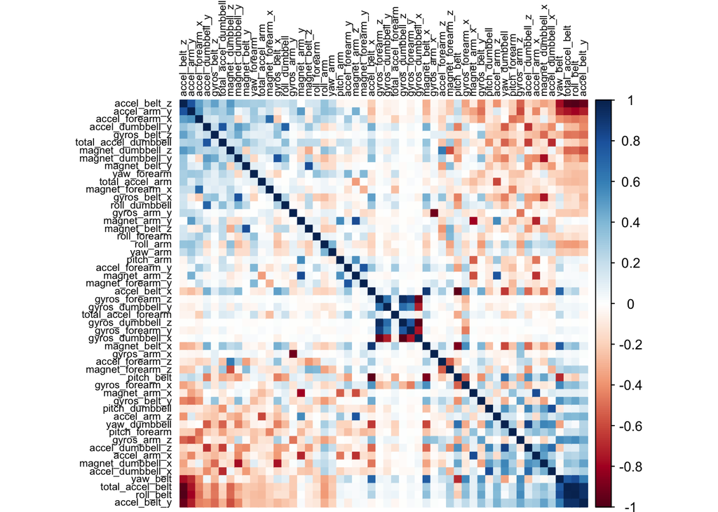

```r
Corr_Matrix <- cor(Training[, -53])
corrplot(Corr_Matrix, order = "FPC", method = "color",
         tl.cex = 0.6, tl.col = rgb(0, 0, 0))
```

## Testing Models

##### This data analysis will test four models: *Classification Tree* , *Random Forest*, *Gradient Boosting Method*, *Linear Discriminant Analysis*.

### Random Forest model:

```r
set.seed(4567)

trControl <- trainControl(method="cv", number=10)
mod_rf <- train(classe ~ ., data = Training, method = "rf", trControl=trControl, verbose=FALSE, ntree = 200)
```

[output not shown]

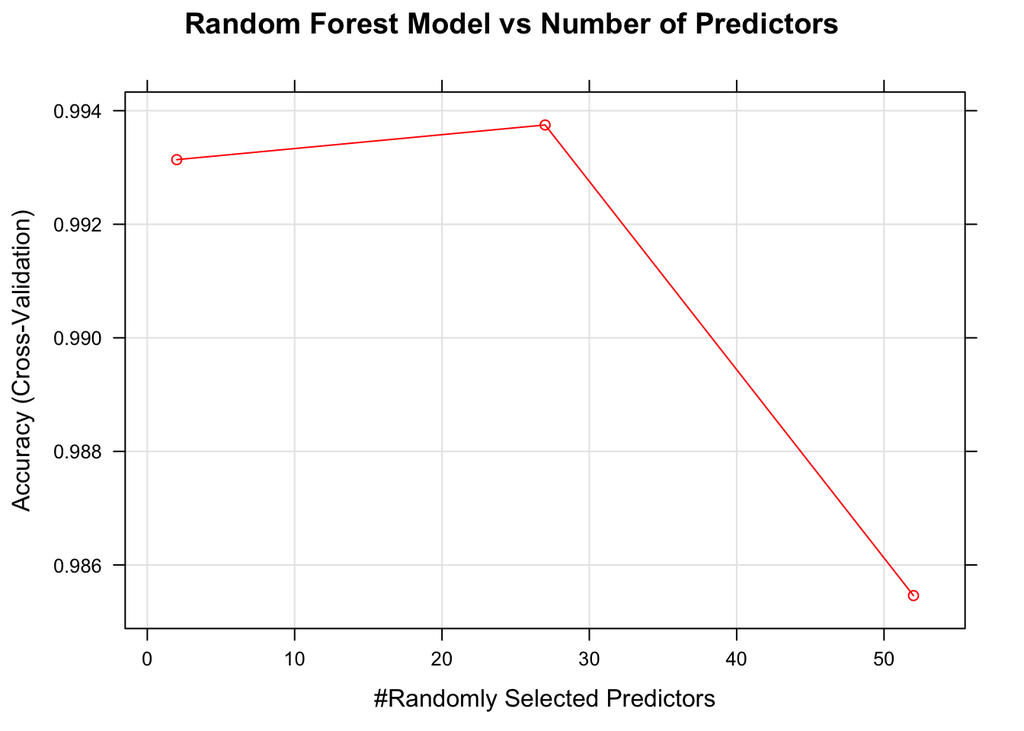

```r
plot(mod_rf,col="red", main="Random Forest Model vs Number of Predictors")
```

#### Validating Random Forest model:

```r
pred_rf <- predict(mod_rf, Testing)
```

```r
ConfMatRF <- confusionMatrix(pred_rf, Testing$classe)
ConfMatRF
```

```
## Confusion Matrix and Statistics
##
##           Reference
## Prediction    A    B    C    D    E
##          A 1393   10    0    0    0
##          B    1  938    5    0    0
##          C    1    1  848    4    0
##          D    0    0    2  800    1
##          E    0    0    0    0  900
##
## Overall Statistics
##
##                Accuracy : 0.9949
##                  95% CI : (0.9925, 0.9967)
##     No Information Rate : 0.2845
##     P-Value [Acc > NIR] : < 2.2e-16
##
##                   Kappa : 0.9936
##
##  Mcnemar's Test P-Value : NA
##
## Statistics by Class:
##
##                      Class: A Class: B Class: C Class: D Class: E
## Sensitivity            0.9986   0.9884   0.9918   0.9950   0.9989
## Specificity            0.9972   0.9985   0.9985   0.9993   1.0000
## Pos Pred Value         0.9929   0.9936   0.9930   0.9963   1.0000
## Neg Pred Value         0.9994   0.9972   0.9983   0.9990   0.9998
## Prevalence             0.2845   0.1935   0.1743   0.1639   0.1837
## Detection Rate         0.2841   0.1913   0.1729   0.1631   0.1835
## Detection Prevalence   0.2861   0.1925   0.1741   0.1637   0.1835
## Balanced Accuracy      0.9979   0.9934   0.9952   0.9971   0.9994
```

Confusion matrix and model accuracy

```r
ConfMatRF$table
```

```
##           Reference
## Prediction    A    B    C    D    E
##          A 1393   10    0    0    0
##          B    1  938    5    0    0
##          C    1    1  848    4    0
##          D    0    0    2  800    1
##          E    0    0    0    0  900
```

#### Accuracy of the Random Forest model:

```r
ConfMatRF$overall[1]
```

```
##  Accuracy
## 0.9949021
```

### Linear Discriminant Analysis Model

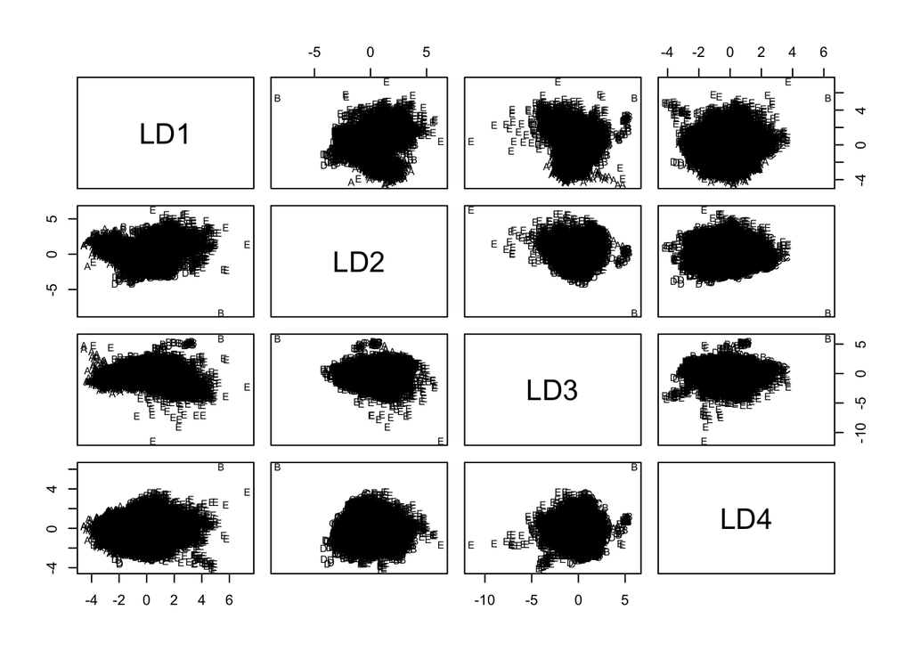

```r
mod_lda <- lda(classe~., data = Training)
plot(mod_lda)
```

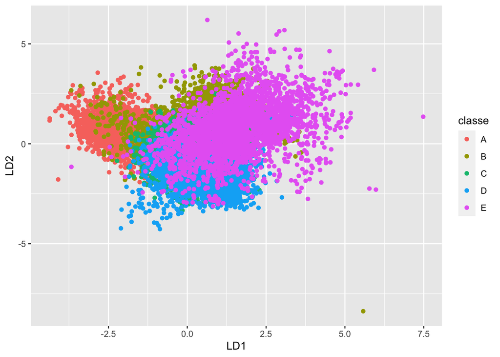

```r
lda.data <- cbind(Training, predict(mod_lda)$x)
ggplot(lda.data, aes(LD1, LD2)) +
  geom_point(aes(color = classe))
```

#### Validating model:

```r
pred_lda <- predict(mod_lda, Testing)
```

#### Accuracy of Linear Discriminant Analysis model:

```r
mean(pred_lda$class==Testing$classe)
```

```
## [1] 0.6969821
```

##### Accuracy of model is around 70%.

#### Misclasification rate:

```r
lda.pred = (pred_lda$class)
lda.error = mean(Testing$classe != lda.pred)
lda.error
```

```
## [1] 0.3030179
```

### Gradient Boosting Method

```r
Model_GBM <- train(classe~., data=Training, method="gbm", trControl=trControl, verbose=FALSE)
```

```r
print(Model_GBM)
```

```
## Stochastic Gradient Boosting
##
## 14718 samples
##    52 predictor
##     5 classes: 'A', 'B', 'C', 'D', 'E'
##
## No pre-processing
## Resampling: Cross-Validated (10 fold)
## Summary of sample sizes: 13247, 13246, 13245, 13245, 13245, 13247, ...
## Resampling results across tuning parameters:
##
##   interaction.depth  n.trees  Accuracy   Kappa
##   1                   50      0.7511889  0.6844740
##   1                  100      0.8209689  0.7733998
##   1                  150      0.8535819  0.8147349
##   2                   50      0.8533781  0.8142125
##   2                  100      0.9056248  0.8805588
##   2                  150      0.9292031  0.9103939
##   3                   50      0.8955038  0.8677166
##   3                  100      0.9420436  0.9266591
##   3                  150      0.9621551  0.9521181
##
## Tuning parameter 'shrinkage' was held constant at a value of 0.1
##
## Tuning parameter 'n.minobsinnode' was held constant at a value of 10
## Accuracy was used to select the optimal model using the largest value.
## The final values used for the model were n.trees = 150, interaction.depth =
##  3, shrinkage = 0.1 and n.minobsinnode = 10.
```

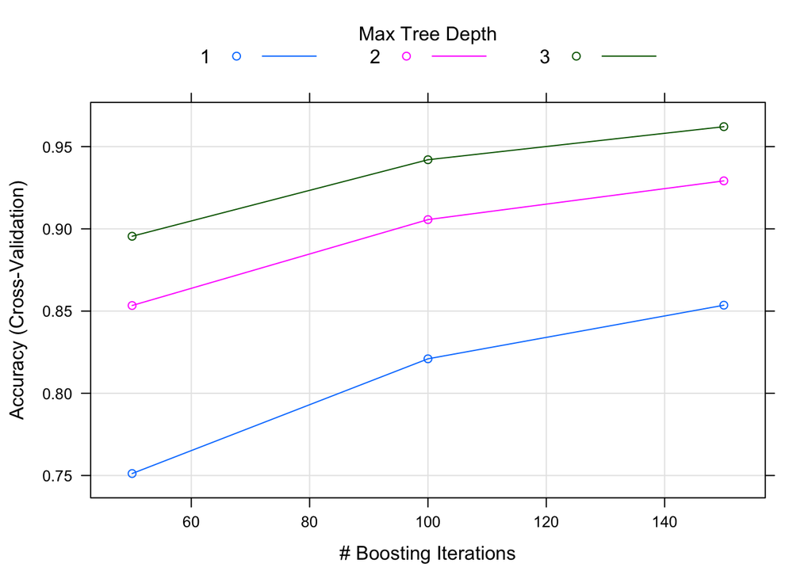

```r
plot(Model_GBM)
```

#### Validating the boosting method model:

```r
Model_GBMpred <- predict(Model_GBM,newdata=Testing)

ConfMatGBM <- confusionMatrix(Model_GBMpred, Testing$classe)
ConfMatGBM$table
```

```
##           Reference
## Prediction    A    B    C    D    E
##          A 1379   36    0    1    0
##          B   11  896   34    0   10
##          C    4   16  810   26    5
##          D    1    1   10  769   13
##          E    0    0    1    8  873
```

#### Accuracy of the model:

```r
ConfMatGBM$overall[1]
```

```
## Accuracy
## 0.963907
```

##### Accuracy of the Gradient Boosting Method is high, around 96.4%.

### Classification Tree Model

```r
trControl <- trainControl(method="cv", number=10)
Model_ClassTree <- train(classe~., data=Training, method="rpart", trControl=trControl)
```

```r
Model_ClassTree$finalModel
```

```
## n= 14718
##
## node), split, n, loss, yval, (yprob)
##       * denotes terminal node
##
##  1) root 14718 10533 A (0.28 0.19 0.17 0.16 0.18)
##    2) roll_belt< 130.5 13465  9291 A (0.31 0.21 0.19 0.18 0.11)
##      4) pitch_forearm< -34 1189     3 A (1 0.0025 0 0 0) *
##      5) pitch_forearm>=-34 12276  9288 A (0.24 0.23 0.21 0.2 0.12)
##       10) magnet_dumbbell_y< 439.5 10403  7478 A (0.28 0.18 0.24 0.19 0.11)
##         20) roll_forearm< 124.5 6467  3844 A (0.41 0.19 0.18 0.17 0.059) *
##         21) roll_forearm>=124.5 3936  2633 C (0.077 0.18 0.33 0.23 0.18) *
##       11) magnet_dumbbell_y>=439.5 1873   931 B (0.034 0.5 0.038 0.23 0.19) *
##    3) roll_belt>=130.5 1253    11 E (0.0088 0 0 0 0.99) *
```

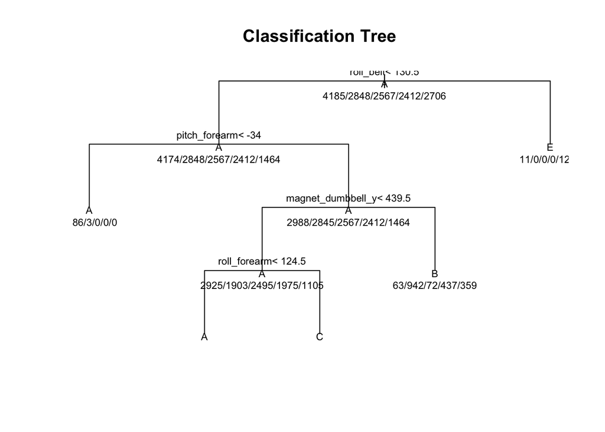

```r
plot(Model_ClassTree$finalModel, uniform=TRUE,
      main="Classification Tree")
text(Model_ClassTree$finalModel, use.n=TRUE, all=TRUE, cex=.7)
```

```r
print(Model_ClassTree)
```

```
## CART
##
## 14718 samples
##    52 predictor
##     5 classes: 'A', 'B', 'C', 'D', 'E'
##
## No pre-processing
## Resampling: Cross-Validated (10 fold)
## Summary of sample sizes: 13245, 13247, 13246, 13247, 13247, 13247, ...
## Resampling results across tuning parameters:
##
##   cp          Accuracy   Kappa
##   0.03569733  0.5040773  0.35163107
##   0.05949555  0.4054068  0.19051168
##   0.11687079  0.3257347  0.06298508
##
## Accuracy was used to select the optimal model using the largest value.
## The final value used for the model was cp = 0.03569733.
```

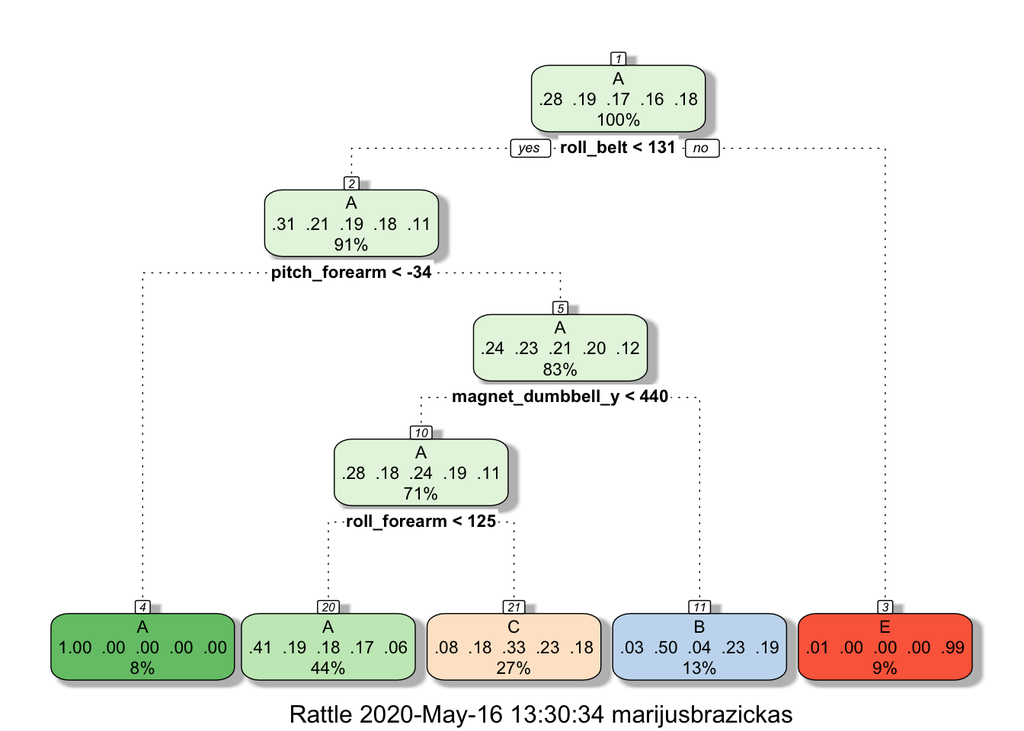

```r
fancyRpartPlot(Model_ClassTree$finalModel)
```

#### Validating Classification Tree model using Testing data set:

```r
Model_ClassTreePred <- predict(Model_ClassTree,newdata=Testing)
```

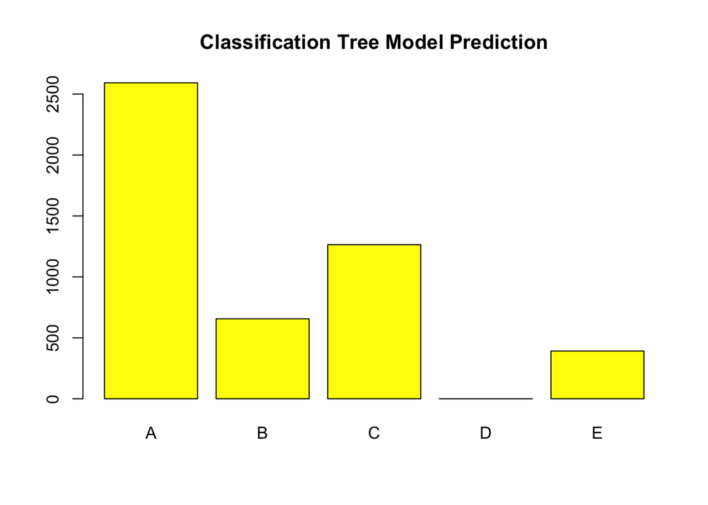

```r
plot(Model_ClassTreePred, main="Classification Tree Model Prediction" , col="yellow")
```

```r
confMatClassTree <- confusionMatrix(Model_ClassTreePred, Testing$classe)

confMatClassTree
```

```
## Confusion Matrix and Statistics
##
##           Reference
## Prediction    A    B    C    D    E
##          A 1274  390  401  386  141
##          B   18  344   36  131  127
##          C  100  215  418  287  244
##          D    0    0    0    0    0
##          E    3    0    0    0  389
##
## Overall Statistics
##
##                Accuracy : 0.4945
##                  95% CI : (0.4804, 0.5086)
##     No Information Rate : 0.2845
##     P-Value [Acc > NIR] : < 2.2e-16
##
##                   Kappa : 0.3385
##
##  Mcnemar's Test P-Value : NA
##
## Statistics by Class:
##
##                      Class: A Class: B Class: C Class: D Class: E
## Sensitivity            0.9133  0.36249  0.48889   0.0000  0.43174
## Specificity            0.6244  0.92111  0.79106   1.0000  0.99925
## Pos Pred Value         0.4915  0.52439  0.33070      NaN  0.99235
## Neg Pred Value         0.9477  0.85758  0.87995   0.8361  0.88652
## Prevalence             0.2845  0.19352  0.17435   0.1639  0.18373
## Detection Rate         0.2598  0.07015  0.08524   0.0000  0.07932
## Detection Prevalence   0.5285  0.13377  0.25775   0.0000  0.07993
## Balanced Accuracy      0.7688  0.64180  0.63997   0.5000  0.71550
```

```r
confMatClassTree$table
```

```
##           Reference
## Prediction    A    B    C    D    E
##          A 1274  390  401  386  141
##          B   18  344   36  131  127
##          C  100  215  418  287  244
##          D    0    0    0    0    0
##          E    3    0    0    0  389
```

#### Accuracy of the Classification Tree model:

```r
confMatClassTree$overall[1]
```

```
##  Accuracy
## 0.4944943
```

##### Accuracy of Classification Tree model is around 50% which is very low so this model will not predict well

## Conclusions

##### The most accurate results were using *Random Forests model*.

#### Validating Random Forests model with test dataset:

```r
FinalPred <- predict(mod_rf,newdata=testing)
table(FinalPred)
```

```
## FinalPred
## A B C D E
## 7 8 1 1 3
```

```r
print(FinalPred)
```

```
##  [1] B A B A A E D B A A B C B A E E A B B B
## Levels: A B C D E
```